# Risk Factor Analysis

## Outcome Variable

**Outcome Variable:** wasted

## Predictor Variables

**Intervention Variable:** hfoodsec

**Adjustment Set:**

- arm
- sex
- W_mage
- meducyrs
- feducyrs
- hhwealth_quart
- vagbrth
- W_nrooms
- W_nchldlt5
- brthmon
- W_parity
- impfloor
- impsan
- safeh20
- delta_W_mage
- delta_meducyrs
- delta_feducyrs
- delta_hhwealth_quart
- delta_vagbrth
- delta_W_nrooms
- delta_W_nchldlt5
- delta_brthmon
- delta_W_parity
- delta_impfloor
- delta_impsan
- delta_safeh20

## Stratifying Variables

The analysis was stratified on these variable(s):

- agecat
- studyid
- country

## Data Summary

| agecat | studyid | country | hfoodsec | wasted | n_cell | n |
| --- | --- | --- | --- | --- | --- | --- |
| Birth | GMS-Nepal | NEPAL | Food Secure | 0 | 347 | 620 |
| Birth | GMS-Nepal | NEPAL | Food Secure | 1 | 95 | 620 |
| Birth | GMS-Nepal | NEPAL | Mildly Food Insecure | 0 | 87 | 620 |
| Birth | GMS-Nepal | NEPAL | Mildly Food Insecure | 1 | 13 | 620 |
| Birth | GMS-Nepal | NEPAL | Food Insecure | 0 | 59 | 620 |
| Birth | GMS-Nepal | NEPAL | Food Insecure | 1 | 19 | 620 |
| Birth | JiVitA-3 | BANGLADESH | Food Secure | 0 | 5214 | 11763 |
| Birth | JiVitA-3 | BANGLADESH | Food Secure | 1 | 583 | 11763 |
| Birth | JiVitA-3 | BANGLADESH | Mildly Food Insecure | 0 | 3524 | 11763 |
| Birth | JiVitA-3 | BANGLADESH | Mildly Food Insecure | 1 | 423 | 11763 |
| Birth | JiVitA-3 | BANGLADESH | Food Insecure | 0 | 1787 | 11763 |
| Birth | JiVitA-3 | BANGLADESH | Food Insecure | 1 | 232 | 11763 |
| Birth | JiVitA-4 | BANGLADESH | Food Secure | 0 | 1093 | 2383 |
| Birth | JiVitA-4 | BANGLADESH | Food Secure | 1 | 112 | 2383 |
| Birth | JiVitA-4 | BANGLADESH | Mildly Food Insecure | 0 | 776 | 2383 |
| Birth | JiVitA-4 | BANGLADESH | Mildly Food Insecure | 1 | 94 | 2383 |
| Birth | JiVitA-4 | BANGLADESH | Food Insecure | 0 | 275 | 2383 |
| Birth | JiVitA-4 | BANGLADESH | Food Insecure | 1 | 33 | 2383 |
| Birth | MAL-ED | BANGLADESH | Food Secure | 0 | 113 | 162 |
| Birth | MAL-ED | BANGLADESH | Food Secure | 1 | 25 | 162 |
| Birth | MAL-ED | BANGLADESH | Mildly Food Insecure | 0 | 3 | 162 |
| Birth | MAL-ED | BANGLADESH | Mildly Food Insecure | 1 | 0 | 162 |
| Birth | MAL-ED | BANGLADESH | Food Insecure | 0 | 17 | 162 |
| Birth | MAL-ED | BANGLADESH | Food Insecure | 1 | 4 | 162 |
| Birth | MAL-ED | BRAZIL | Food Secure | 0 | 0 | 26 |
| Birth | MAL-ED | BRAZIL | Food Secure | 1 | 0 | 26 |
| Birth | MAL-ED | BRAZIL | Mildly Food Insecure | 0 | 4 | 26 |
| Birth | MAL-ED | BRAZIL | Mildly Food Insecure | 1 | 0 | 26 |
| Birth | MAL-ED | BRAZIL | Food Insecure | 0 | 21 | 26 |
| Birth | MAL-ED | BRAZIL | Food Insecure | 1 | 1 | 26 |

[output cut: 168 more lines]

The following strata were considered:

- agecat: 24 months, studyid: GMS-Nepal, country: NEPAL
- agecat: 24 months, studyid: JiVitA-3, country: BANGLADESH
- agecat: 24 months, studyid: JiVitA-4, country: BANGLADESH
- agecat: 24 months, studyid: MAL-ED, country: BANGLADESH
- agecat: 24 months, studyid: MAL-ED, country: BRAZIL
- agecat: 24 months, studyid: MAL-ED, country: INDIA
- agecat: 24 months, studyid: MAL-ED, country: NEPAL
- agecat: 24 months, studyid: MAL-ED, country: PERU
- agecat: 24 months, studyid: MAL-ED, country: SOUTH AFRICA
- agecat: 24 months, studyid: NIH-Birth, country: BANGLADESH
- agecat: 24 months, studyid: NIH-Crypto, country: BANGLADESH
- agecat: 6 months, studyid: GMS-Nepal, country: NEPAL
- agecat: 6 months, studyid: JiVitA-3, country: BANGLADESH
- agecat: 6 months, studyid: JiVitA-4, country: BANGLADESH
- agecat: 6 months, studyid: MAL-ED, country: BANGLADESH
- agecat: 6 months, studyid: MAL-ED, country: BRAZIL
- agecat: 6 months, studyid: MAL-ED, country: INDIA
- agecat: 6 months, studyid: MAL-ED, country: NEPAL
- agecat: 6 months, studyid: MAL-ED, country: PERU
- agecat: 6 months, studyid: MAL-ED, country: SOUTH AFRICA
- agecat: 6 months, studyid: NIH-Birth, country: BANGLADESH
- agecat: 6 months, studyid: NIH-Crypto, country: BANGLADESH
- agecat: Birth, studyid: GMS-Nepal, country: NEPAL
- agecat: Birth, studyid: JiVitA-3, country: BANGLADESH
- agecat: Birth, studyid: JiVitA-4, country: BANGLADESH
- agecat: Birth, studyid: MAL-ED, country: BANGLADESH
- agecat: Birth, studyid: MAL-ED, country: BRAZIL
- agecat: Birth, studyid: MAL-ED, country: INDIA
- agecat: Birth, studyid: MAL-ED, country: NEPAL
- agecat: Birth, studyid: MAL-ED, country: PERU
- agecat: Birth, studyid: MAL-ED, country: SOUTH AFRICA
- agecat: Birth, studyid: NIH-Birth, country: BANGLADESH
- agecat: Birth, studyid: NIH-Crypto, country: BANGLADESH

### Dropped Strata

Some strata were dropped due to rare outcomes:

- agecat: Birth, studyid: MAL-ED, country: BANGLADESH
- agecat: Birth, studyid: MAL-ED, country: BRAZIL
- agecat: Birth, studyid: MAL-ED, country: INDIA
- agecat: Birth, studyid: MAL-ED, country: NEPAL
- agecat: Birth, studyid: MAL-ED, country: PERU
- agecat: Birth, studyid: MAL-ED, country: SOUTH AFRICA
- agecat: 6 months, studyid: GMS-Nepal, country: NEPAL
- agecat: 6 months, studyid: MAL-ED, country: BANGLADESH
- agecat: 6 months, studyid: MAL-ED, country: BRAZIL
- agecat: 6 months, studyid: MAL-ED, country: INDIA
- agecat: 6 months, studyid: MAL-ED, country: NEPAL
- agecat: 6 months, studyid: MAL-ED, country: PERU
- agecat: 6 months, studyid: MAL-ED, country: SOUTH AFRICA
- agecat: 6 months, studyid: NIH-Birth, country: BANGLADESH
- agecat: 6 months, studyid: NIH-Crypto, country: BANGLADESH
- agecat: 24 months, studyid: MAL-ED, country: BANGLADESH
- agecat: 24 months, studyid: MAL-ED, country: BRAZIL
- agecat: 24 months, studyid: MAL-ED, country: INDIA
- agecat: 24 months, studyid: MAL-ED, country: NEPAL
- agecat: 24 months, studyid: MAL-ED, country: PERU
- agecat: 24 months, studyid: MAL-ED, country: SOUTH AFRICA
- agecat: 24 months, studyid: NIH-Birth, country: BANGLADESH

## Methods Detail

We’re interested in the causal parameters $E[Y_a]$ for all values of $a \in \mathcal{A}$. These parameters represent the mean outcome if, possibly contrary to fact, we intervened to set all units to have $A=a$. Under the randomization and positivity assumptions, these are identified by the statistical parameters $\psi_a=E_W[E_{Y|A,W}(Y|A=a,W)]$. In addition, we’re interested in the mean of $Y$, $E[Y]$ under no intervention (the observed mean). We will estimate these parameters by using SuperLearner to fit the relevant likelihood factors – $E_{Y|A,W}(Y|A=a,W)$ and $p(A=a|W)$, and then updating our likelihood fit using a joint TMLE.

For unadjusted analyses ($W=\{\}$), initial likelihoods were estimated using Lrnr_glm to estimate the simple $E(Y|A)$ and Lrnr_mean to estimate $p(A)$. For adjusted analyses, a small library containing Lrnr_glmnet, Lrnr_xgboost, and Lrnr_mean was used.

Having estimated these parameters, we will then use the delta method to estimate relative risks and attributable risks relative to a prespecified baseline level of $A$.

# Results Detail

## Results Plots

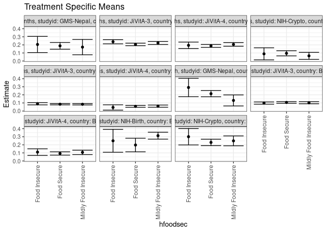

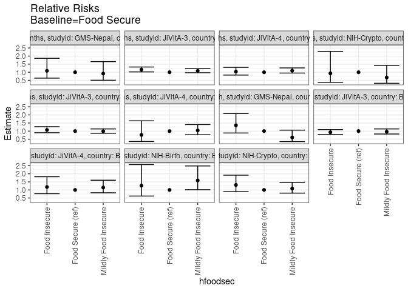

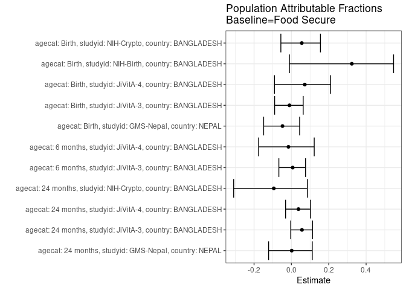

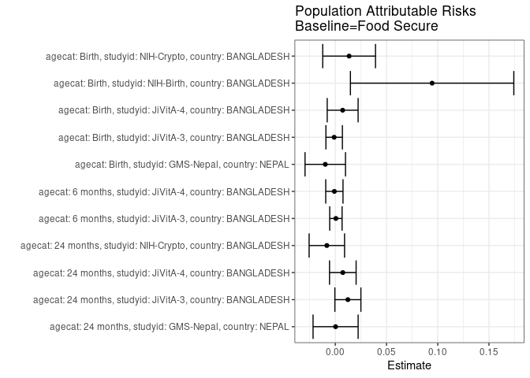

## Results Table

### Parameter: TSM

| agecat | studyid | country | intervention_level | baseline_level | estimate | ci_lower | ci_upper |
| --- | --- | --- | --- | --- | --- | --- | --- |
| Birth | GMS-Nepal | NEPAL | Food Secure | NA | 0.2146270 | 0.1761242 | 0.2531298 |
| Birth | GMS-Nepal | NEPAL | Mildly Food Insecure | NA | 0.1308536 | 0.0625235 | 0.1991837 |
| Birth | GMS-Nepal | NEPAL | Food Insecure | NA | 0.2912847 | 0.1774714 | 0.4050979 |
| Birth | JiVitA-3 | BANGLADESH | Food Secure | NA | 0.1063495 | 0.0962427 | 0.1164563 |
| Birth | JiVitA-3 | BANGLADESH | Mildly Food Insecure | NA | 0.1025732 | 0.0898077 | 0.1153387 |
| Birth | JiVitA-3 | BANGLADESH | Food Insecure | NA | 0.0985675 | 0.0846087 | 0.1125263 |
| Birth | JiVitA-4 | BANGLADESH | Food Secure | NA | 0.0931067 | 0.0727557 | 0.1134577 |
| Birth | JiVitA-4 | BANGLADESH | Mildly Food Insecure | NA | 0.1068551 | 0.0796516 | 0.1340586 |
| Birth | JiVitA-4 | BANGLADESH | Food Insecure | NA | 0.1100357 | 0.0694187 | 0.1506528 |
| Birth | NIH-Birth | BANGLADESH | Food Secure | NA | 0.1976744 | 0.1134327 | 0.2819162 |
| Birth | NIH-Birth | BANGLADESH | Mildly Food Insecure | NA | 0.3134658 | 0.2707092 | 0.3562224 |
| Birth | NIH-Birth | BANGLADESH | Food Insecure | NA | 0.2500000 | 0.1084286 | 0.3915714 |
| Birth | NIH-Crypto | BANGLADESH | Food Secure | NA | 0.2297900 | 0.1898533 | 0.2697267 |
| Birth | NIH-Crypto | BANGLADESH | Mildly Food Insecure | NA | 0.2491708 | 0.1882435 | 0.3100981 |
| Birth | NIH-Crypto | BANGLADESH | Food Insecure | NA | 0.3004391 | 0.1988282 | 0.4020500 |
| 6 months | JiVitA-3 | BANGLADESH | Food Secure | NA | 0.0840661 | 0.0762158 | 0.0919165 |
| 6 months | JiVitA-3 | BANGLADESH | Mildly Food Insecure | NA | 0.0833063 | 0.0750056 | 0.0916070 |
| 6 months | JiVitA-3 | BANGLADESH | Food Insecure | NA | 0.0899191 | 0.0762029 | 0.1036353 |
| 6 months | JiVitA-4 | BANGLADESH | Food Secure | NA | 0.0578395 | 0.0461439 | 0.0695352 |
| 6 months | JiVitA-4 | BANGLADESH | Mildly Food Insecure | NA | 0.0602719 | 0.0468691 | 0.0736748 |
| 6 months | JiVitA-4 | BANGLADESH | Food Insecure | NA | 0.0441597 | 0.0113620 | 0.0769574 |
| 24 months | GMS-Nepal | NEPAL | Food Secure | NA | 0.1883830 | 0.1469358 | 0.2298302 |
| 24 months | GMS-Nepal | NEPAL | Mildly Food Insecure | NA | 0.1725195 | 0.0775055 | 0.2675336 |
| 24 months | GMS-Nepal | NEPAL | Food Insecure | NA | 0.2052322 | 0.1048107 | 0.3056538 |
| 24 months | JiVitA-3 | BANGLADESH | Food Secure | NA | 0.2055309 | 0.1898767 | 0.2211851 |
| 24 months | JiVitA-3 | BANGLADESH | Mildly Food Insecure | NA | 0.2238155 | 0.2050459 | 0.2425851 |
| 24 months | JiVitA-3 | BANGLADESH | Food Insecure | NA | 0.2391838 | 0.2133262 | 0.2650415 |
| 24 months | JiVitA-4 | BANGLADESH | Food Secure | NA | 0.1875003 | 0.1692074 | 0.2057933 |
| 24 months | JiVitA-4 | BANGLADESH | Mildly Food Insecure | NA | 0.2058121 | 0.1836428 | 0.2279814 |
| 24 months | JiVitA-4 | BANGLADESH | Food Insecure | NA | 0.1945219 | 0.1545251 | 0.2345186 |
| 24 months | NIH-Crypto | BANGLADESH | Food Secure | NA | 0.0958084 | 0.0642126 | 0.1274042 |
| 24 months | NIH-Crypto | BANGLADESH | Mildly Food Insecure | NA | 0.0645161 | 0.0212336 | 0.1077986 |
| 24 months | NIH-Crypto | BANGLADESH | Food Insecure | NA | 0.0892857 | 0.0145275 | 0.1640439 |

### Parameter: E(Y)

| agecat | studyid | country | intervention_level | baseline_level | estimate | ci_lower | ci_upper |
| --- | --- | --- | --- | --- | --- | --- | --- |
| Birth | GMS-Nepal | NEPAL | NA | NA | 0.2048387 | 0.1730454 | 0.2366321 |
| Birth | JiVitA-3 | BANGLADESH | NA | NA | 0.1052453 | 0.0993428 | 0.1111477 |
| Birth | JiVitA-4 | BANGLADESH | NA | NA | 0.1002937 | 0.0848872 | 0.1157003 |
| Birth | NIH-Birth | BANGLADESH | NA | NA | 0.2921739 | 0.2549711 | 0.3293768 |
| Birth | NIH-Crypto | BANGLADESH | NA | NA | 0.2432815 | 0.2116319 | 0.2749310 |
| 6 months | JiVitA-3 | BANGLADESH | NA | NA | 0.0846457 | 0.0798459 | 0.0894454 |
| 6 months | JiVitA-4 | BANGLADESH | NA | NA | 0.0569343 | 0.0480657 | 0.0658029 |
| 24 months | GMS-Nepal | NEPAL | NA | NA | 0.1886792 | 0.1535311 | 0.2238274 |
| 24 months | JiVitA-3 | BANGLADESH | NA | NA | 0.2178266 | 0.2079286 | 0.2277246 |
| 24 months | JiVitA-4 | BANGLADESH | NA | NA | 0.1948467 | 0.1815077 | 0.2081857 |
| 24 months | NIH-Crypto | BANGLADESH | NA | NA | 0.0875486 | 0.0630907 | 0.1120065 |

### Parameter: RR

| agecat | studyid | country | intervention_level | baseline_level | estimate | ci_lower | ci_upper |
| --- | --- | --- | --- | --- | --- | --- | --- |
| Birth | GMS-Nepal | NEPAL | Food Secure | Food Secure | 1.0000000 | 1.0000000 | 1.000000 |
| Birth | GMS-Nepal | NEPAL | Mildly Food Insecure | Food Secure | 0.6096791 | 0.3509557 | 1.059133 |
| Birth | GMS-Nepal | NEPAL | Food Insecure | Food Secure | 1.3571669 | 0.8826493 | 2.086788 |
| Birth | JiVitA-3 | BANGLADESH | Food Secure | Food Secure | 1.0000000 | 1.0000000 | 1.000000 |
| Birth | JiVitA-3 | BANGLADESH | Mildly Food Insecure | Food Secure | 0.9644917 | 0.8203865 | 1.133910 |
| Birth | JiVitA-3 | BANGLADESH | Food Insecure | Food Secure | 0.9268262 | 0.7859673 | 1.092930 |
| Birth | JiVitA-4 | BANGLADESH | Food Secure | Food Secure | 1.0000000 | 1.0000000 | 1.000000 |
| Birth | JiVitA-4 | BANGLADESH | Mildly Food Insecure | Food Secure | 1.1476635 | 0.8230465 | 1.600312 |
| Birth | JiVitA-4 | BANGLADESH | Food Insecure | Food Secure | 1.1818246 | 0.7684343 | 1.817604 |
| Birth | NIH-Birth | BANGLADESH | Food Secure | Food Secure | 1.0000000 | 1.0000000 | 1.000000 |
| Birth | NIH-Birth | BANGLADESH | Mildly Food Insecure | Food Secure | 1.5857681 | 1.0137016 | 2.480671 |
| Birth | NIH-Birth | BANGLADESH | Food Insecure | Food Secure | 1.2647059 | 0.6225768 | 2.569130 |
| Birth | NIH-Crypto | BANGLADESH | Food Secure | Food Secure | 1.0000000 | 1.0000000 | 1.000000 |
| Birth | NIH-Crypto | BANGLADESH | Mildly Food Insecure | Food Secure | 1.0843414 | 0.8032337 | 1.463828 |
| Birth | NIH-Crypto | BANGLADESH | Food Insecure | Food Secure | 1.3074508 | 0.8941417 | 1.911808 |
| 6 months | JiVitA-3 | BANGLADESH | Food Secure | Food Secure | 1.0000000 | 1.0000000 | 1.000000 |
| 6 months | JiVitA-3 | BANGLADESH | Mildly Food Insecure | Food Secure | 0.9909621 | 0.8659112 | 1.134072 |
| 6 months | JiVitA-3 | BANGLADESH | Food Insecure | Food Secure | 1.0696236 | 0.8988899 | 1.272786 |
| 6 months | JiVitA-4 | BANGLADESH | Food Secure | Food Secure | 1.0000000 | 1.0000000 | 1.000000 |
| 6 months | JiVitA-4 | BANGLADESH | Mildly Food Insecure | Food Secure | 1.0420541 | 0.7732379 | 1.404324 |
| 6 months | JiVitA-4 | BANGLADESH | Food Insecure | Food Secure | 0.7634859 | 0.3565511 | 1.634859 |
| 24 months | GMS-Nepal | NEPAL | Food Secure | Food Secure | 1.0000000 | 1.0000000 | 1.000000 |
| 24 months | GMS-Nepal | NEPAL | Mildly Food Insecure | Food Secure | 0.9157914 | 0.5059842 | 1.657510 |
| 24 months | GMS-Nepal | NEPAL | Food Insecure | Food Secure | 1.0894414 | 0.6370067 | 1.863218 |
| 24 months | JiVitA-3 | BANGLADESH | Food Secure | Food Secure | 1.0000000 | 1.0000000 | 1.000000 |
| 24 months | JiVitA-3 | BANGLADESH | Mildly Food Insecure | Food Secure | 1.0889626 | 0.9710052 | 1.221249 |
| 24 months | JiVitA-3 | BANGLADESH | Food Insecure | Food Secure | 1.1637366 | 1.0223841 | 1.324632 |
| 24 months | JiVitA-4 | BANGLADESH | Food Secure | Food Secure | 1.0000000 | 1.0000000 | 1.000000 |
| 24 months | JiVitA-4 | BANGLADESH | Mildly Food Insecure | Food Secure | 1.0976626 | 0.9501870 | 1.268028 |
| 24 months | JiVitA-4 | BANGLADESH | Food Insecure | Food Secure | 1.0374480 | 0.8259790 | 1.303058 |
| 24 months | NIH-Crypto | BANGLADESH | Food Secure | Food Secure | 1.0000000 | 1.0000000 | 1.000000 |
| 24 months | NIH-Crypto | BANGLADESH | Mildly Food Insecure | Food Secure | 0.6733871 | 0.3188651 | 1.422075 |
| 24 months | NIH-Crypto | BANGLADESH | Food Insecure | Food Secure | 0.9319196 | 0.3789294 | 2.291916 |

### Parameter: PAR

| agecat | studyid | country | intervention_level | baseline_level | estimate | ci_lower | ci_upper |
| --- | --- | --- | --- | --- | --- | --- | --- |
| Birth | GMS-Nepal | NEPAL | Food Secure | NA | -0.0097883 | -0.0295321 | 0.0099555 |
| Birth | JiVitA-3 | BANGLADESH | Food Secure | NA | -0.0011043 | -0.0091447 | 0.0069362 |
| Birth | JiVitA-4 | BANGLADESH | Food Secure | NA | 0.0071871 | -0.0078895 | 0.0222637 |
| Birth | NIH-Birth | BANGLADESH | Food Secure | NA | 0.0944995 | 0.0147631 | 0.1742359 |
| Birth | NIH-Crypto | BANGLADESH | Food Secure | NA | 0.0134915 | -0.0122674 | 0.0392503 |
| 6 months | JiVitA-3 | BANGLADESH | Food Secure | NA | 0.0005795 | -0.0054609 | 0.0066200 |
| 6 months | JiVitA-4 | BANGLADESH | Food Secure | NA | -0.0009052 | -0.0093357 | 0.0075252 |
| 24 months | GMS-Nepal | NEPAL | Food Secure | NA | 0.0002962 | -0.0216998 | 0.0222923 |
| 24 months | JiVitA-3 | BANGLADESH | Food Secure | NA | 0.0122957 | -0.0004016 | 0.0249930 |
| 24 months | JiVitA-4 | BANGLADESH | Food Secure | NA | 0.0073463 | -0.0056322 | 0.0203249 |
| 24 months | NIH-Crypto | BANGLADESH | Food Secure | NA | -0.0082597 | -0.0255539 | 0.0090344 |

### Parameter: PAF

| agecat | studyid | country | intervention_level | baseline_level | estimate | ci_lower | ci_upper |
| --- | --- | --- | --- | --- | --- | --- | --- |
| Birth | GMS-Nepal | NEPAL | Food Secure | NA | -0.0477854 | -0.1485274 | 0.0441202 |
| Birth | JiVitA-3 | BANGLADESH | Food Secure | NA | -0.0104922 | -0.0898365 | 0.0630755 |
| Birth | JiVitA-4 | BANGLADESH | Food Secure | NA | 0.0716604 | -0.0905838 | 0.2097677 |
| Birth | NIH-Birth | BANGLADESH | Food Secure | NA | 0.3234358 | -0.0106683 | 0.5470926 |
| Birth | NIH-Crypto | BANGLADESH | Food Secure | NA | 0.0554562 | -0.0565142 | 0.1555599 |
| 6 months | JiVitA-3 | BANGLADESH | Food Secure | NA | 0.0068467 | -0.0671573 | 0.0757188 |
| 6 months | JiVitA-4 | BANGLADESH | Food Secure | NA | -0.0158998 | -0.1755797 | 0.1220907 |
| 24 months | GMS-Nepal | NEPAL | Food Secure | NA | 0.0015701 | -0.1220881 | 0.1116006 |
| 24 months | JiVitA-3 | BANGLADESH | Food Secure | NA | 0.0564473 | -0.0035882 | 0.1128914 |
| 24 months | JiVitA-4 | BANGLADESH | Food Secure | NA | 0.0377031 | -0.0312252 | 0.1020243 |
| 24 months | NIH-Crypto | BANGLADESH | Food Secure | NA | -0.0943446 | -0.3091652 | 0.0852260 |